# Case 1 Study: Cyclistic Bike-Share R Markdown

Stephany Lamas

2025-06-27

```r
library(tidyverse)
```

## Introduction

This case study is one of three case studies available when completing the Google Data Analytics Professional Certificate. Upon completion the student, may qualify to receive the certificate.

## Case Study Description

## Case Study Question

How do annual members and casual riders use Cyclistic bikes differently?

## Update Log

06/26/25 - Stephany Lamas - prepared data for analysis 06/27/2025 Stephany Lamas - 06/28/2025 - Stephany Lamas 06/29/2025 - Stephany Lamas

## Case Study Deliverables

1. A clear statement of the business task
2. A description of all data sources used
3. Documentation of any cleaning or manipulation of data
4. A summary of your analysis
5. Supporting visualizations and key findings
6. Your top three recommendations based on your analysis

## Ask ———

# Guiding questions

What is the problem you are trying to solve? The problem I am trying to solve is understanding how annual members and casual riders use Cyclistic bikes differently.

How can your insights drive business decisions? The insights I find will contribute to the decision of the final marketing strategy used to convert casual riders to annual members.

# Key tasks

Identify the business task The business task is to determine the marketing strategy used to convert casual riders to annual members

Consider key stakeholders The stakeholders include the executive board of Cyclistic

# Deliverables

A clear statement of the business task Cyclistic will determine a marketing program to use based on the marketing director’s hypothesis that an increase of annual members equates to an increase in the company’s success. The marketing program decision will be driven by the insights provided by the marketing analysis team. The junior analysts will identify the behavior of annual members vs casual riders as part of this effort.

## Datasets

Two sets were analyzed in this case study. 1. Divvy Trips 2019 Q1 Dataset was installed as .csv file from the Google Sheets link provided in the case study assignment. After being imported the data was assigned to the variable “q1_2019” for ease of reference during the analysis.

```r
q1_2019 <- read.csv("divvy_trips_2019_q1.csv")
summary(q1_2019)
```

```
##     trip_id          start_time          end_time             bikeid
##  Min.   :21742443   Length:365069      Length:365069      Min.   :   1
##  1st Qu.:21848765   Class :character   Class :character   1st Qu.:1777
##  Median :21961829   Mode  :character   Mode  :character   Median :3489
##  Mean   :21960872                                         Mean   :3429
##  3rd Qu.:22071823                                         3rd Qu.:5157
##  Max.   :22178528                                         Max.   :6471
##
##  tripduration       from_station_id from_station_name  to_station_id
##  Length:365069      Min.   :  2.0   Length:365069      Min.   :  2.0
##  Class :character   1st Qu.: 76.0   Class :character   1st Qu.: 76.0
##  Mode  :character   Median :170.0   Mode  :character   Median :168.0
##                     Mean   :198.1                      Mean   :198.6
##                     3rd Qu.:287.0                      3rd Qu.:287.0
##                     Max.   :665.0                      Max.   :665.0
##
##  to_station_name      usertype            gender            birthyear
##  Length:365069      Length:365069      Length:365069      Min.   :1900
##  Class :character   Class :character   Class :character   1st Qu.:1975
##  Mode  :character   Mode  :character   Mode  :character   Median :1985
##                                                           Mean   :1982
##                                                           3rd Qu.:1990
##                                                           Max.   :2003
##                                                           NA's   :18023
```

2. Divvy trips 2020 Q1 Dataset was installed as .csv file from the Google Sheets link provided in the case study assignment. After being imported the data was assigned to the variable “q1_2020” for ease of reference during the analysis.

```r
q1_2020 <- read.csv("divvy_trips_2020_q1.csv")
summary(q1_2020)
```

```
##    ride_id          rideable_type       started_at          ended_at
##  Length:426887      Length:426887      Length:426887      Length:426887
##  Class :character   Class :character   Class :character   Class :character
##  Mode  :character   Mode  :character   Mode  :character   Mode  :character
##
##
##
##
##  start_station_name start_station_id end_station_name   end_station_id
##  Length:426887      Min.   :  2.0    Length:426887      Min.   :  2.0
##  Class :character   1st Qu.: 77.0    Class :character   1st Qu.: 77.0
##  Mode  :character   Median :176.0    Mode  :character   Median :175.0
##                     Mean   :209.8                       Mean   :209.3
##                     3rd Qu.:298.0                       3rd Qu.:297.0
##                     Max.   :675.0                       Max.   :675.0
##                                                         NA's   :1
##    start_lat       start_lng         end_lat         end_lng
##  Min.   :41.74   Min.   :-87.77   Min.   :41.74   Min.   :-87.77
##  1st Qu.:41.88   1st Qu.:-87.66   1st Qu.:41.88   1st Qu.:-87.66
##  Median :41.89   Median :-87.64   Median :41.89   Median :-87.64
##  Mean   :41.90   Mean   :-87.64   Mean   :41.90   Mean   :-87.64
##  3rd Qu.:41.92   3rd Qu.:-87.63   3rd Qu.:41.92   3rd Qu.:-87.63
##  Max.   :42.06   Max.   :-87.55   Max.   :42.06   Max.   :-87.55
##                                   NA's   :1       NA's   :1
##  member_casual
##  Length:426887
##  Class :character
##  Mode  :character
##
##
##
##
```

## Prepare -

# Guiding Questions

Where is the data located? The data is located under the project folder

How is the data organized? The data was was exported from a Google Sheet dataset to a .csv file.

Are there issues with bias or credibility in this data? Does your data ROCCC? There are no issues with bias or credibility as these datasets are from the Cyclistic company itself. The data is reliable because it comes the from the company itself. The data is orginal as the data formatting and number of columns is different from 2019 to 2020. The data is comprehensive. The data is current and cited.

How are you addressing licensing, privacy, security and accessibility? For the purpose of this case study licensing, privacy, security and accessibility is not being taken into great consideration because we are analyzing psuedo data.

How did you verify the data’s integrity? I verified the data’s integrity by reviewing the data’s columns, number of columns, data types, and relativity to the task at hand. I did note some transformations that will hhave to be completed.

How does it help you answer your question? It shows the behavior of each type of member, their frequent docking stations, trip durations and locations traveled during the trip.

# Key Tasks

Download data and store it appropriately. Done.

Identify how it’s organized. Done

Sort and filter the data. Done

Determine the credibility of the data. Done

#Deliverable Description of all data sources used The only data sources used are the q1 datasets from 2019 and 2020.

##Process ——–

#Guiding Questions What tools are you choosing and why? I am choosing the R Posit Cloud Studio because for the ease of wrangling the data and to practice and refine my R programming skills.

Have you ensured your data’s integrity? Yes

What steps have you taken to ensure that your data is clean? I have completed transformations on the data individually

How can you verify that your data is clean and ready to analyze? I can verify that the data is clean and ready for analysis when there are blanks removed, repeat data and all other noise is removed.

Have you documented your cleaning process so you can review and share those results? Yes, these changes have been made in the cleaning process.

#Key Tasks Check the data for errors. Done.

Choose your tools R and Posit Cloud Studio

Transform the data so you can work with it effectively. In Work

Document the cleaning process.

Removed Columns

Removed gender and birthyear columns as they are not necessary to the analysis. Our task does not focus on the gender identity or age of the customers; only the behavior between customers with different membership types.

#Deliverable Documentation of any cleaning or manipulation of data This R markdown is the documentation of the data manipulation

## Analyze ———

# Guiding questions

How should you organize your data to perform analysis on it? Has your data been properly formatted? What surprises did you discover in the data? What trends or relationships did you find in the data? How will these insights help answer your business questions?

# Key tasks

Aggregate your data so it’s useful and accessible. Organize and format your data. Perform calculations. Identify trends and relationships.

# Deliverable

A summary of your analysis

Load Libraries — loaded libraries tidyverse and conflicted

Set Defaults — set defaults choices for conflicted package choices

```r
library(conflicted)
conflict_prefer("filter", "dplyr")
```

```
## [conflicted] Will prefer dplyr::filter over any other package.
```

```r
# [conflicted] Will prefer dplyr::filter over any other package.
conflict_prefer("lag", "dplyr")
```

```
## [conflicted] Will prefer dplyr::lag over any other package.
```

```r
# [conflicted] Will prefer dplyr::lag over any other package.
```

Collect Data (Step 1) —

```r
q1_2019 <- read.csv("divvy_trips_2019_q1.csv")
q1_2020 <- read.csv("divvy_trips_2020_q1.csv")
```

Wrangle and Combine Data into a Single File (Step 2) —

```r
#comparing column names
colnames(q1_2019)
```

```
##  [1] "trip_id"           "start_time"        "end_time"
##  [4] "bikeid"            "tripduration"      "from_station_id"
##  [7] "from_station_name" "to_station_id"     "to_station_name"
## [10] "usertype"          "gender"            "birthyear"
```

```r
colnames(q1_2020)
```

```
##  [1] "ride_id"            "rideable_type"      "started_at"
##  [4] "ended_at"           "start_station_name" "start_station_id"
##  [7] "end_station_name"   "end_station_id"     "start_lat"
## [10] "start_lng"          "end_lat"            "end_lng"
## [13] "member_casual"
```

```r
#renamed columns in 2019 q1 data to fit format of 2020 q1 data since the 2020 format will be used moving forward
library(dplyr)

(q1_2019 <- rename(q1_2019
                   ,ride_id = trip_id
                   ,rideable_type = bikeid
                   ,started_at = start_time
                   ,ended_at = end_time
                   ,start_station_name = from_station_name
                   ,start_station_id = from_station_id
                   ,end_station_name = to_station_name
                   ,end_station_id = to_station_id
                   ,member_casual = usertype
                   ))
```

| ride_id | started_at | ended_at | rideable_type | tripduration | start_station_id | start_station_name | end_station_id | end_station_name | member_casual | gender | birthyear |
| --- | --- | --- | --- | --- | --- | --- | --- | --- | --- | --- | --- |
| 21742443 | 2019-01-01 0:04:37 | 2019-01-01 0:11:07 | 2167 | 390 | 199 | Wabash Ave & Grand Ave | 84 | Milwaukee Ave & Grand Ave | Subscriber | Male | 1989 |
| 21742444 | 2019-01-01 0:08:13 | 2019-01-01 0:15:34 | 4386 | 441 | 44 | State St & Randolph St | 624 | Dearborn St & Van Buren St (*) | Subscriber | Female | 1990 |
| 21742445 | 2019-01-01 0:13:23 | 2019-01-01 0:27:12 | 1524 | 829 | 15 | Racine Ave & 18th St | 644 | Western Ave & Fillmore St (*) | Subscriber | Female | 1994 |
| 21742446 | 2019-01-01 0:13:45 | 2019-01-01 0:43:28 | 252 | 1,783.00 | 123 | California Ave & Milwaukee Ave | 176 | Clark St & Elm St | Subscriber | Male | 1993 |
| 21742447 | 2019-01-01 0:14:52 | 2019-01-01 0:20:56 | 1170 | 364 | 173 | Mies van der Rohe Way & Chicago Ave | 35 | Streeter Dr & Grand Ave | Subscriber | Male | 1994 |
| 21742448 | 2019-01-01 0:15:33 | 2019-01-01 0:19:09 | 2437 | 216 | 98 | LaSalle St & Washington St | 49 | Dearborn St & Monroe St | Subscriber | Female | 1983 |
| 21742449 | 2019-01-01 0:16:06 | 2019-01-01 0:19:03 | 2708 | 177 | 98 | LaSalle St & Washington St | 49 | Dearborn St & Monroe St | Subscriber | Male | 1984 |
| 21742450 | 2019-01-01 0:18:41 | 2019-01-01 0:20:21 | 2796 | 100 | 211 | St. Clair St & Erie St | 142 | McClurg Ct & Erie St | Subscriber | Male | 1990 |
| 21742451 | 2019-01-01 0:18:43 | 2019-01-01 0:47:30 | 6205 | 1,727.00 | 150 | Fort Dearborn Dr & 31st St | 148 | State St & 33rd St | Subscriber | Male | 1995 |
| 21742452 | 2019-01-01 0:19:18 | 2019-01-01 0:24:54 | 3939 | 336 | 268 | Lake Shore Dr & North Blvd | 141 | Clark St & Lincoln Ave | Subscriber | Male | 1996 |

[output cut: 9990 more lines]

```r
#inspect data
str(q1_2019)
```

```
## 'data.frame':    365069 obs. of  12 variables:
##  $ ride_id           : int  21742443 21742444 21742445 21742446 21742447 21742448 21742449 21742450 21742451 21742452 ...
##  $ started_at        : chr  "2019-01-01 0:04:37" "2019-01-01 0:08:13" "2019-01-01 0:13:23" "2019-01-01 0:13:45" ...
##  $ ended_at          : chr  "2019-01-01 0:11:07" "2019-01-01 0:15:34" "2019-01-01 0:27:12" "2019-01-01 0:43:28" ...
##  $ rideable_type     : int  2167 4386 1524 252 1170 2437 2708 2796 6205 3939 ...
##  $ tripduration      : chr  "390" "441" "829" "1,783.00" ...
##  $ start_station_id  : int  199 44 15 123 173 98 98 211 150 268 ...
##  $ start_station_name: chr  "Wabash Ave & Grand Ave" "State St & Randolph St" "Racine Ave & 18th St" "California Ave & Milwaukee Ave" ...
##  $ end_station_id    : int  84 624 644 176 35 49 49 142 148 141 ...
##  $ end_station_name  : chr  "Milwaukee Ave & Grand Ave" "Dearborn St & Van Buren St (*)" "Western Ave & Fillmore St (*)" "Clark St & Elm St" ...
##  $ member_casual     : chr  "Subscriber" "Subscriber" "Subscriber" "Subscriber" ...
##  $ gender            : chr  "Male" "Female" "Female" "Male" ...
##  $ birthyear         : int  1989 1990 1994 1993 1994 1983 1984 1990 1995 1996 ...
```

```r
str(q1_2020)
```

```
## 'data.frame':    426887 obs. of  13 variables:
##  $ ride_id           : chr  "EACB19130B0CDA4A" "8FED874C809DC021" "789F3C21E472CA96" "C9A388DAC6ABF313" ...
##  $ rideable_type     : chr  "docked_bike" "docked_bike" "docked_bike" "docked_bike" ...
##  $ started_at        : chr  "2020-01-21 20:06:59" "2020-01-30 14:22:39" "2020-01-09 19:29:26" "2020-01-06 16:17:07" ...
##  $ ended_at          : chr  "2020-01-21 20:14:30" "2020-01-30 14:26:22" "2020-01-09 19:32:17" "2020-01-06 16:25:56" ...
##  $ start_station_name: chr  "Western Ave & Leland Ave" "Clark St & Montrose Ave" "Broadway & Belmont Ave" "Clark St & Randolph St" ...
##  $ start_station_id  : int  239 234 296 51 66 212 96 96 212 38 ...
##  $ end_station_name  : chr  "Clark St & Leland Ave" "Southport Ave & Irving Park Rd" "Wilton Ave & Belmont Ave" "Fairbanks Ct & Grand Ave" ...
##  $ end_station_id    : int  326 318 117 24 212 96 212 212 96 100 ...
##  $ start_lat         : num  42 42 41.9 41.9 41.9 ...
##  $ start_lng         : num  -87.7 -87.7 -87.6 -87.6 -87.6 ...
##  $ end_lat           : num  42 42 41.9 41.9 41.9 ...
##  $ end_lng           : num  -87.7 -87.7 -87.7 -87.6 -87.6 ...
##  $ member_casual     : chr  "member" "member" "member" "member" ...
```

```r
# convert ride_id and rideable_type to character so that they can stack correctly
q1_2019 <-  mutate(q1_2019, ride_id = as.character(ride_id)
                   ,rideable_type = as.character(rideable_type))

#create dataframe with both datasets
all_trips <- bind_rows(q1_2019, q1_2020)#, q3_2019)#, q4_2019, q1_2020)

#remove unncecessary columns
all_trips <- all_trips %>% select(-c(start_lat, start_lng, end_lat, end_lng, birthyear, gender,  "tripduration"))
```

Prep for Analysis (Step 3) —

```r
library(data.table)
#inspect combined dataframe "all_trips"
colnames(all_trips)
```

```
## [1] "ride_id"            "started_at"         "ended_at"
## [4] "rideable_type"      "start_station_id"   "start_station_name"
## [7] "end_station_id"     "end_station_name"   "member_casual"
```

```r
#calculate number of rows
nrow(all_trips)
```

```
## [1] 791956
```

```r
#791956

#calculate dimensions of data frame
dim(all_trips)
```

```
## [1] 791956      9
```

```r
#791956 x 9

#first six rows of dataframe
head(all_trips)
```

|  | ride_id | started_at | ended_at | rideable_type | start_station_id | start_station_name | end_station_id | end_station_name | member_casual |
| --- | --- | --- | --- | --- | --- | --- | --- | --- | --- |
| 1 | 21742443 | 2019-01-01 0:04:37 | 2019-01-01 0:11:07 | 2167 | 199 | Wabash Ave & Grand Ave | 84 | Milwaukee Ave & Grand Ave | Subscriber |
| 2 | 21742444 | 2019-01-01 0:08:13 | 2019-01-01 0:15:34 | 4386 | 44 | State St & Randolph St | 624 | Dearborn St & Van Buren St (*) | Subscriber |
| 3 | 21742445 | 2019-01-01 0:13:23 | 2019-01-01 0:27:12 | 1524 | 15 | Racine Ave & 18th St | 644 | Western Ave & Fillmore St (*) | Subscriber |
| 4 | 21742446 | 2019-01-01 0:13:45 | 2019-01-01 0:43:28 | 252 | 123 | California Ave & Milwaukee Ave | 176 | Clark St & Elm St | Subscriber |
| 5 | 21742447 | 2019-01-01 0:14:52 | 2019-01-01 0:20:56 | 1170 | 173 | Mies van der Rohe Way & Chicago Ave | 35 | Streeter Dr & Grand Ave | Subscriber |
| 6 | 21742448 | 2019-01-01 0:15:33 | 2019-01-01 0:19:09 | 2437 | 98 | LaSalle St & Washington St | 49 | Dearborn St & Monroe St | Subscriber |

```r
#review list of columns and data types
str(all_trips)
```

```
## 'data.frame':    791956 obs. of  9 variables:
##  $ ride_id           : chr  "21742443" "21742444" "21742445" "21742446" ...
##  $ started_at        : chr  "2019-01-01 0:04:37" "2019-01-01 0:08:13" "2019-01-01 0:13:23" "2019-01-01 0:13:45" ...
##  $ ended_at          : chr  "2019-01-01 0:11:07" "2019-01-01 0:15:34" "2019-01-01 0:27:12" "2019-01-01 0:43:28" ...
##  $ rideable_type     : chr  "2167" "4386" "1524" "252" ...
##  $ start_station_id  : int  199 44 15 123 173 98 98 211 150 268 ...
##  $ start_station_name: chr  "Wabash Ave & Grand Ave" "State St & Randolph St" "Racine Ave & 18th St" "California Ave & Milwaukee Ave" ...
##  $ end_station_id    : int  84 624 644 176 35 49 49 142 148 141 ...
##  $ end_station_name  : chr  "Milwaukee Ave & Grand Ave" "Dearborn St & Van Buren St (*)" "Western Ave & Fillmore St (*)" "Clark St & Elm St" ...
##  $ member_casual     : chr  "Subscriber" "Subscriber" "Subscriber" "Subscriber" ...
```

```r
#statistcal summary of data
summary(all_trips)
```

```
##    ride_id           started_at          ended_at         rideable_type
##  Length:791956      Length:791956      Length:791956      Length:791956
##  Class :character   Class :character   Class :character   Class :character
##  Mode  :character   Mode  :character   Mode  :character   Mode  :character
##
##
##
##
##  start_station_id start_station_name end_station_id  end_station_name
##  Min.   :  2.0    Length:791956      Min.   :  2.0   Length:791956
##  1st Qu.: 77.0    Class :character   1st Qu.: 77.0   Class :character
##  Median :174.0    Mode  :character   Median :174.0   Mode  :character
##  Mean   :204.4                       Mean   :204.4
##  3rd Qu.:291.0                       3rd Qu.:291.0
##  Max.   :675.0                       Max.   :675.0
##                                      NA's   :1
##  member_casual
##  Length:791956
##  Class :character
##  Mode  :character
##
##
##
##
```

Addressed Problems —

1. In the “member_casual” column, there are two names for members (“member” and “Subscriber”) and two names for casual riders (“Customer” and “casual”). We will need to consolidate that from four to two labels.

```r
#Subscriber to Member
all_trips <- mutate(all_trips, member_casual = ifelse(member_casual == "Subscriber", "member", member_casual))

#Customer to Casual
all_trips <- mutate(all_trips, member_casual = ifelse(member_casual == "Customer", "casual", member_casual))
```

2. The data can only be aggregated at the ride-level, which is too granular. We will want to add some additional columns of data – such as day, month, year – that provide additional opportunities to aggregate the data.

```r
#create date column
all_trips$date <- as.Date(all_trips$started_at)

#create month column
all_trips$month <- format(as.Date(all_trips$date), "%m")

#create day column
all_trips$day <- format(as.Date(all_trips$date), "%d")

#create year column
all_trips$year <- format(as.Date(all_trips$date), "%Y")

#create week column
all_trips$day_of_week <- format(as.Date(all_trips$date), "%A")
```

3. We will want to add a calculated field for length of ride since the 2020Q1 data did not have the “tripduration” column. We will add “ride_length” to the entire dataframe for consistency.

```r
all_trips$ride_length <- difftime(all_trips$ended_at,all_trips$started_at)

#changing values to numeric
is.factor(all_trips$ride_length)
```

```
## [1] FALSE
```

```r
all_trips$ride_length <- as.numeric(as.character(all_trips$ride_length))
is.numeric(all_trips$ride_length)
```

```
## [1] TRUE
```

4. There are some rides where tripduration shows up as negative, including several hundred rides where Divvy took bikes out of circulation for Quality Control reasons. We will want to delete these rides.

```r
#removes rides where the bikes are under quality inspection or have negative ride lengths
all_trips_v2 <- all_trips[!(all_trips$start_station_name == "HQ QR" | all_trips$ride_length<0),]
```

##Conduct Descriptive Analysis (Step 4) — # Ride Length Analysis

```r
mean(all_trips_v2$ride_length) #straight average (total ride length / rides)
```

```
## [1] 1189.176
```

```r
#[1] 1189.459

median(all_trips_v2$ride_length) #midpoint number in the ascending array of ride lengths
```

```
## [1] 539
```

```r
#[1] 539

max(all_trips_v2$ride_length) #longest ride
```

```
## [1] 10628422
```

```r
#[1] 10632022

min(all_trips_v2$ride_length) #shortest ride
```

```
## [1] 1
```

```r
#[1] 1

#summary provides all the data necessary that was generated in the code above
summary(all_trips_v2$ride_length)
```

```
##     Min.  1st Qu.   Median     Mean  3rd Qu.     Max.
##        1      331      539     1189      912 10628422
```

#Members and Casual Users Analysis

```r
aggregate(all_trips_v2$ride_length ~ all_trips_v2$member_casual, FUN = mean)
```

| all_trips_v2$member_casual | all_trips_v2$ride_length |
| --- | --- |
| casual | 5370.7685 |
| member | 795.1324 |

```r
# all_trips_v2$member_casual all_trips_v2$ride_length
#1                     casual                5372.7839
#2                     member                 795.2523

aggregate(all_trips_v2$ride_length ~ all_trips_v2$member_casual, FUN = median)
```

| all_trips_v2$member_casual | all_trips_v2$ride_length |
| --- | --- |
| casual | 1393 |
| member | 508 |

```r
#  all_trips_v2$member_casual all_trips_v2$ride_length
#1                     casual                     1393
#2                     member                      508

aggregate(all_trips_v2$ride_length ~ all_trips_v2$member_casual, FUN = max)
```

| all_trips_v2$member_casual | all_trips_v2$ride_length |
| --- | --- |
| casual | 10628422 |
| member | 6096428 |

```r
#  all_trips_v2$member_casual all_trips_v2$ride_length
#1                     casual                 10632022
#2                     member                  6096428

aggregate(all_trips_v2$ride_length ~ all_trips_v2$member_casual, FUN = min)
```

| all_trips_v2$member_casual | all_trips_v2$ride_length |
| --- | --- |
| casual | 2 |
| member | 1 |

```r
#  all_trips_v2$member_casual all_trips_v2$ride_length
#1                     casual                        2
#2                     member                        1
```

# Average Ride Time

```r
# See the average ride time by each day for members vs casual users
aggregate(all_trips_v2$ride_length ~ all_trips_v2$member_casual + all_trips_v2$day_of_week, FUN = mean)
```

| all_trips_v2$member_casual | all_trips_v2$day_of_week | all_trips_v2$ride_length |
| --- | --- | --- |
| casual | Friday | 6088.9402 |
| member | Friday | 796.6713 |
| casual | Monday | 4750.7627 |
| member | Monday | 822.2134 |
| casual | Saturday | 4946.4956 |
| member | Saturday | 973.7094 |
| casual | Sunday | 5059.1813 |
| member | Sunday | 972.1609 |
| casual | Thursday | 8450.1557 |
| member | Thursday | 707.2093 |

[output cut: 4 more lines]

```r
#   all_trips_v2$member_casual all_trips_v2$day_of_week all_trips_v2$ride_length
#1                      casual                   Friday                6090.7373
#2                      member                   Friday                 796.7338
#3                      casual                   Monday                4752.0504
#4                      member                   Monday                 822.3112
#5                      casual                 Saturday                4950.7708
#6                      member                 Saturday                 974.0730
#7                      casual                   Sunday                5061.3044
#8                      member                   Sunday                 972.9383
#9                      casual                 Thursday                8451.6669
#10                     member                 Thursday                 707.2093
#11                     casual                  Tuesday                4561.8039
#12                     member                  Tuesday                 769.4416
#13                     casual                Wednesday                4480.3724
#14                     member                Wednesday                 711.9838

#order day of week
all_trips_v2$day_of_week <- ordered(all_trips_v2$day_of_week, levels=c("Sunday", "Monday", "Tuesday", "Wednesday", "Thursday", "Friday", "Saturday"))


#lets run this again now that the days are ordered
aggregate(all_trips_v2$ride_length ~ all_trips_v2$member_casual + all_trips_v2$day_of_week, FUN = mean)
```

| all_trips_v2$member_casual | all_trips_v2$day_of_week | all_trips_v2$ride_length |
| --- | --- | --- |
| casual | Sunday | 5059.1813 |
| member | Sunday | 972.1609 |
| casual | Monday | 4750.7627 |
| member | Monday | 822.2134 |
| casual | Tuesday | 4560.8190 |
| member | Tuesday | 769.4416 |
| casual | Wednesday | 4480.3724 |
| member | Wednesday | 711.9838 |
| casual | Thursday | 8450.1557 |
| member | Thursday | 707.2093 |

[output cut: 4 more lines]

```r
# analyze ridership data by type and weekday
all_trips_v2 %>% mutate(weekday = lubridate::wday(started_at, label = TRUE)) %>%  group_by(member_casual, weekday) %>%  summarise(number_of_rides = n(),average_duration = mean(ride_length)) %>% arrange(member_casual, weekday)
```

| member_casual | weekday | number_of_rides | average_duration |
| --- | --- | --- | --- |
| casual | Sun | 18652 | 5059.1813 |
| casual | Mon | 5591 | 4750.7627 |
| casual | Tue | 7311 | 4560.8190 |
| casual | Wed | 7690 | 4480.3724 |
| casual | Thu | 7147 | 8450.1557 |
| casual | Fri | 8013 | 6088.9402 |
| casual | Sat | 13473 | 4946.4956 |
| member | Sun | 60197 | 972.1609 |
| member | Mon | 110430 | 822.2134 |
| member | Tue | 127974 | 769.4416 |

[output cut: 4 more lines]

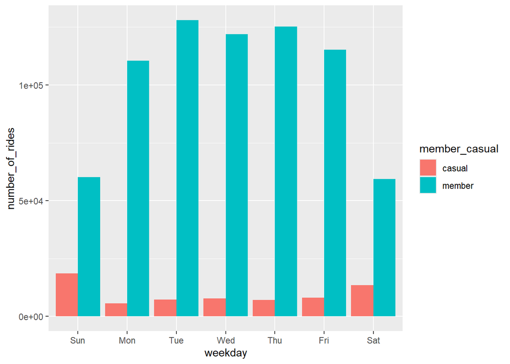

```r
# Let's visualize the number of rides by rider type
all_trips_v2 %>%
  mutate(weekday = lubridate::wday(started_at, label = TRUE)) %>%
  group_by(member_casual, weekday) %>%
  summarise(number_of_rides = n()
            ,average_duration = mean(ride_length)) %>%
  arrange(member_casual, weekday)  %>%
  ggplot(aes(x = weekday, y = number_of_rides, fill = member_casual)) +
  geom_col(position = "dodge")
```